# ggplot2 - Data Visualization

Ben Bellman  
August 28, 2018

### Base R Graphics

- Base functions for graphics are ugly and outdated
- However, they can be useful in a pinch, especially `plot()`
  - Good example of methods in R
  - Different functionality for different classes
  - `plot.histogram()` vs. `plot.xy()`
  - Packages can add new methods
  - When in doubt, give `plot()` a try!

### Advantages of ggplot2

- Standard function and syntax for any plot, regardless of style
- Uses logic similar to dplyr and piping
- Full suite of functions for customizing graphs
- Clean and professional visual styles
- Lots of accessory packages, like `ggmap` and `gganimate`

### Logic of ggplot2

- Initialize with `ggplot()`function
- Define data and `aes()` arguments:
  - Columns for x and y axes
  - Data groupings, etc.
- Define plot type (geometry), color schemes, labels, etc. with additional functions
  - These can have their own `aes()` settings
- Connect functions using `+` operator, like `%>%` in `dplyr`

### Some aes() arguments

| Argument | Property |
| --- | --- |
| x | x values |
| y | y values |
| col | color of line/point |
| fill | color of area |
| alpha | transparency |
| size | size of point/line |
| shape | point symbol |

### Setting up

We'll start with the White House salaries data from the `dplyr` slides

```r
library(tidyverse)
library(here)

salaries <- read_csv(here("data","white-house-salaries.csv"))

# create the tenure variable
salaries <- salaries %>%
  rename(name = employee_name) %>%
  arrange(name) %>%
  group_by(name) %>%
  mutate(tenure = rank(year))
```

### Starting

Once we've initialized with `ggplot()`, we add a geometry feature to generate a basic graph

```r
ggplot(salaries, aes(x = year, y = salary)) +
  geom_point()
```

### Starting a plot

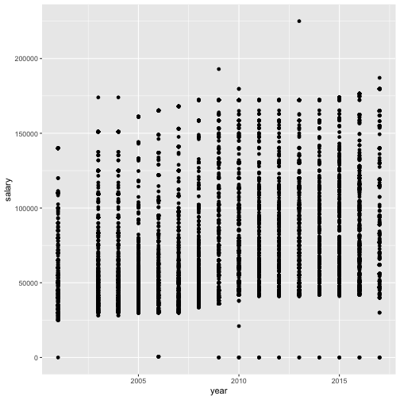

### Starting a plot

- When using new plot types, I like to look up its page on the package website
- Lets take a look at the `geom_point()` documentation and see some ways it can be used:
- https://ggplot2.tidyverse.org/reference/geom_point.html

### Building geometries

```r
ggplot(salaries, aes(x = year, y = salary)) +
  geom_point(alpha = .1) +
  geom_smooth(aes(col = gender, fill = gender), method = "loess")
```

### Building geometries

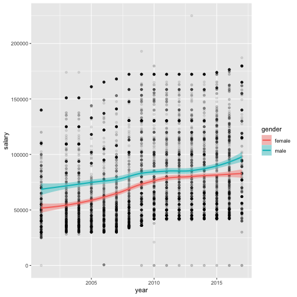

### Labels

There are functions for changing plot text, axis formats, and specifying colors and legends

```r
ggplot(salaries, aes(x = year, y = salary)) +
  geom_point(alpha = .05) +                              # alpha sets transparency
  geom_smooth(aes(col = gender), method = "loess") +     # color by gender
  labs(x = "Year",                                       # change labels
       y = "Employee Salary for Year ($)",
       title = "White House Salaries Since 2001") +
  scale_color_manual(name = "Gender",                    # set legend attributes
                       values = c("green", "blue"),
                       breaks = c("female", "male"),
                       labels = c("Women", "Men"))
```

### Labels

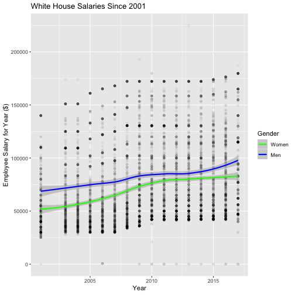

### Themes

Other functions change the overall look if the grid

```r
ggplot(salaries, aes(x = year, y = salary)) +
  geom_point(alpha = .05) +
  geom_smooth(aes(col = gender), method = "loess") +
  theme_minimal()
```

- Also possible to create custom themes

### Themes

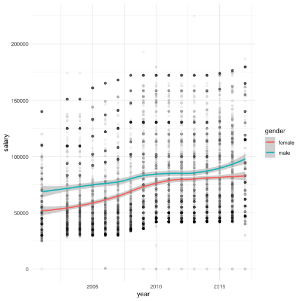

### Scales, colors, and more

- Functions for defining scales
  - `scale_x_continuous()`, `scale_y_discrete()`, `scale_x_log10()`, `scale_y_reverse()`, etc.
- Set scale limits
  - `xlim()` and `ylim()`
- Functions for custom color/symbol schemes
  - Customize with `scale_color_discrete()` and `scale_color_manual()`
  - Reliable schemes with `scale_color_brewer()`
  - `scale_size_manual()`, `scale_shape_manual()`, `scale_alpha_manual()`, etc.

### Scales, colors, and more

- Add extra lines
  - `geom_abline()`, `geom_vline()`, `geom_hline()`
- Define colorbar and legend
  - `guide_colorbar()` and `guide_legend()`
- Faceting multiple plots into one window
  - `facet_grid()` and `facet_wrap()`
- Lots of `theme()` options

### Navigating ggplot2 functions

- There is a huge number of functions in ggplot2
  - Can't memorize them all
  - Important to use documentation and experiment
  - http://ggplot2.tidyverse.org/reference/
- If you can dream it, you can built it!
- Let's look at more examples

### Histogram

Create a histogram of salaries

```r
salaries %>%
ggplot(aes(x = salary)) +
  geom_histogram()
```

### Histogram

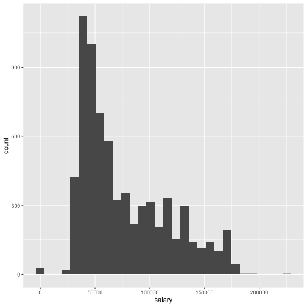

### Histogram

- Let's stack the area according to president and change the bin width

```r
salaries %>%
ggplot(aes(x = salary, fill = president)) +
  geom_histogram(binwidth = 5000)
```

### Histogram

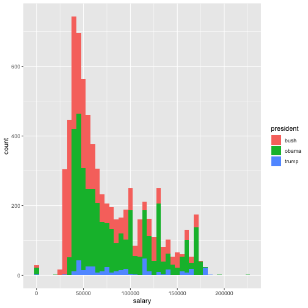

### Box plots

Look at salaries for 1-5 years of tenure

```r
salaries %>%
  filter(tenure >= 1 & tenure <= 5) %>%
  ggplot(aes(tenure, salary, group = tenure)) +
    geom_boxplot(aes(fill = as.factor(tenure))) +
    scale_fill_brewer(palette = "Accent")
```

### Box plots

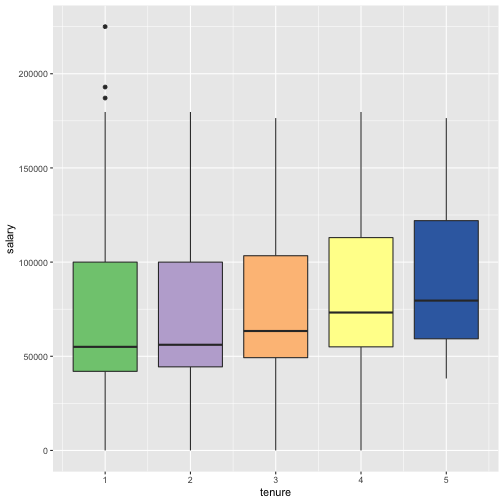

### Violin plots

```r
salaries %>%
  ggplot(aes(tenure, salary, group = as.factor(tenure))) +
    geom_violin(aes(col = as.factor(tenure),
                    fill = as.factor(tenure))) +
    theme(legend.position="none") +
    coord_flip()
```

### Violin plots

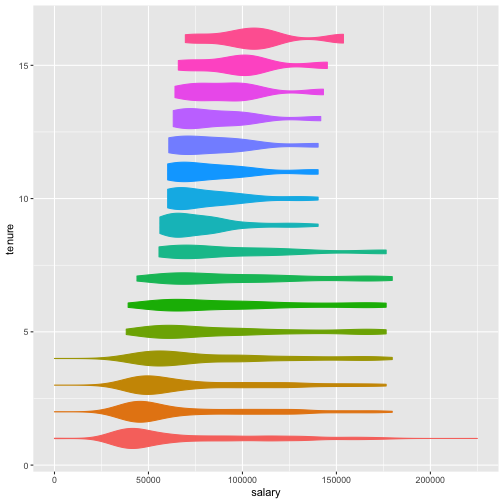

### Density and facet plots

```r
salaries %>%
  ggplot(aes(salary, col = gender, fill = gender)) +
    geom_density(alpha = 0.4) +
    facet_grid(president ~ .)
```

### Density and facet plots

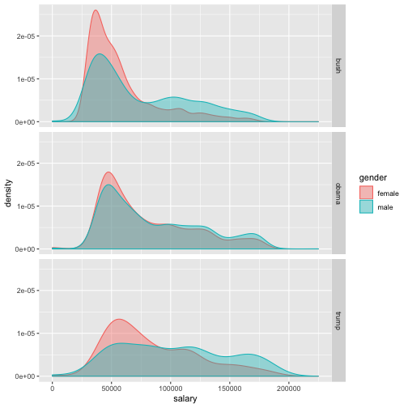

### Saving plots

- It's easy to save plots with `ggsave()`
- It determines output from the extension in the file path
- `here()` is creating a new folder in the project

```r
salaries %>%
  ggplot(aes(salary, col = gender, fill = gender)) +
    geom_density(alpha = 0.4) +
    facet_grid(president ~ .) +
    ggsave(here("results", "test_plot.pdf"), width = 5, height = 4)
```

### Saving plots

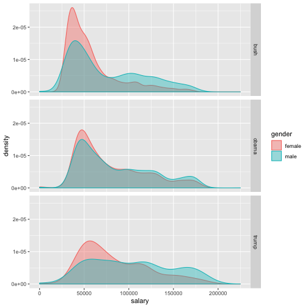

### Questions and Ideas?

- That's all the material for today
- Let's spend rest of time working independently or in groups
  - On this data or own data
  - I can answer any questions you run into
- Or work through questions and ideas together?